# Module 1: Upper East - Homework

## B8474 Real Estate Analytics

**Name:** Leo Bruell

**NOTE FOR SUBMISSION**

- Please rename the notebook as 'module1_homework_fisrtname_lastname', then submit
- Please also submit a `.html` file in the same file name along with this notebook
- Please **DO NOT** submit a `.py` file

To export `.html` file:

- In Jupyter Notebook
  - File -> Download as -> HTML
- In Jupyter Lab
  - File -> Save and Export Notebook As -> HTML

## 0. Data Introduction and Import Packages

In the same directory you will find the data file we'll use for this homework, "manhattan.csv". This is a sample from StreetEasy describing a subset of rental activities in New York. You are supposed to do some simple data manipulations for this dataset and gain insights along with the data processing and analysis.

```python
import numpy as np
import pandas as pd
import missingno as msno
import matplotlib.pyplot as plt
import statsmodels.api as sm
```

## 1. Sample Description

**1.1 Load `manhattan.csv` through pandas**

```python
# insert code here
df = pd.read_csv("../data/manhattan.csv")
```

**1.2 Check the number of observations, data type, mean, median, 25%, and 75% percentiles.**

```python
# insert code here
df.shape # 3,539 rows, 18 columns
```

```
(3539, 18)
```

```python
df.info()
```

```
<class 'pandas.core.frame.DataFrame'>
RangeIndex: 3539 entries, 0 to 3538
Data columns (total 18 columns):
 #   Column            Non-Null Count  Dtype
---  ------            --------------  -----
 0   rental_id         3539 non-null   int64
 1   rent              3539 non-null   int64
 2   bedrooms          3539 non-null   float64
 3   bathrooms         3539 non-null   int64
 4   size_sqft         3539 non-null   int64
 5   min_to_subway     3539 non-null   int64
 6   floor             3539 non-null   float64
 7   building_age_yrs  3539 non-null   int64
 8   no_fee            3539 non-null   int64
 9   has_roofdeck      3539 non-null   int64
 10  has_washer_dryer  3539 non-null   int64
 11  has_doorman       3539 non-null   int64
 12  has_elevator      3539 non-null   int64
 13  has_dishwasher    3539 non-null   int64
 14  has_patio         3539 non-null   int64
 15  has_gym           3539 non-null   int64
 16  neighborhood      3539 non-null   object
 17  borough           3539 non-null   object
dtypes: float64(2), int64(14), object(2)
memory usage: 497.8+ KB
```

```python
df.describe(include=["object","int","float"])
```

|  | rental_id | rent | bedrooms | bathrooms | size_sqft | min_to_subway | floor | building_age_yrs | no_fee | has_roofdeck | has_washer_dryer | has_doorman | has_elevator | has_dishwasher | has_patio | has_gym | neighborhood | borough |
| --- | --- | --- | --- | --- | --- | --- | --- | --- | --- | --- | --- | --- | --- | --- | --- | --- | --- | --- |
| count | 3539.000000 | 3539.000000 | 3539.000000 | 3539.000000 | 3539.000000 | 3539.000000 | 3539.000000 | 3539.000000 | 3539.000000 | 3539.000000 | 3539.000000 | 3539.000000 | 3539.000000 | 3539.000000 | 3539.000000 | 3539.000000 | 3539 | 3539 |
| unique | NaN | NaN | NaN | NaN | NaN | NaN | NaN | NaN | NaN | NaN | NaN | NaN | NaN | NaN | NaN | NaN | 32 | 1 |
| top | NaN | NaN | NaN | NaN | NaN | NaN | NaN | NaN | NaN | NaN | NaN | NaN | NaN | NaN | NaN | NaN | Upper West Side | Manhattan |
| freq | NaN | NaN | NaN | NaN | NaN | NaN | NaN | NaN | NaN | NaN | NaN | NaN | NaN | NaN | NaN | NaN | 579 | 3539 |
| mean | 5332.589997 | 5138.940379 | 1.351936 | 1.366770 | 939.727324 | 4.970896 | 11.908307 | 51.994914 | 0.403504 | 0.154846 | 0.160215 | 0.281153 | 0.294716 | 0.185646 | 0.055100 | 0.174908 | NaN | NaN |
| std | 3311.552136 | 3162.824760 | 0.967595 | 0.599588 | 477.949074 | 5.513589 | 10.960893 | 39.380433 | 0.490669 | 0.361809 | 0.366857 | 0.449625 | 0.455979 | 0.388875 | 0.228208 | 0.379942 | NaN | NaN |
| min | 1.000000 | 1300.000000 | 0.000000 | 0.000000 | 250.000000 | 0.000000 | 0.000000 | 0.000000 | 0.000000 | 0.000000 | 0.000000 | 0.000000 | 0.000000 | 0.000000 | 0.000000 | 0.000000 | NaN | NaN |
| 25% | 2443.500000 | 3150.000000 | 1.000000 | 1.000000 | 613.000000 | 2.000000 | 4.000000 | 15.000000 | 0.000000 | 0.000000 | 0.000000 | 0.000000 | 0.000000 | 0.000000 | 0.000000 | 0.000000 | NaN | NaN |
| 50% | 5128.000000 | 4000.000000 | 1.000000 | 1.000000 | 800.000000 | 4.000000 | 8.000000 | 39.000000 | 0.000000 | 0.000000 | 0.000000 | 0.000000 | 0.000000 | 0.000000 | 0.000000 | 0.000000 | NaN | NaN |
| 75% | 8149.500000 | 6000.000000 | 2.000000 | 2.000000 | 1141.000000 | 6.000000 | 17.000000 | 90.000000 | 1.000000 | 0.000000 | 0.000000 | 1.000000 | 1.000000 | 0.000000 | 0.000000 | 0.000000 | NaN | NaN |
| max | 11349.000000 | 20000.000000 | 5.000000 | 5.000000 | 4800.000000 | 43.000000 | 83.000000 | 180.000000 | 1.000000 | 1.000000 | 1.000000 | 1.000000 | 1.000000 | 1.000000 | 1.000000 | 1.000000 | NaN | NaN |

**1.3 Does this dataset contain missing value?**

*hint: can use a package that we mentioned in class*

From the info method above, we see that every column has the same number of non-null values, and that this number is the same as the number of rows in the dataframe. This means that there are no missing values. Additionally, we can use the missingo package to confirm.

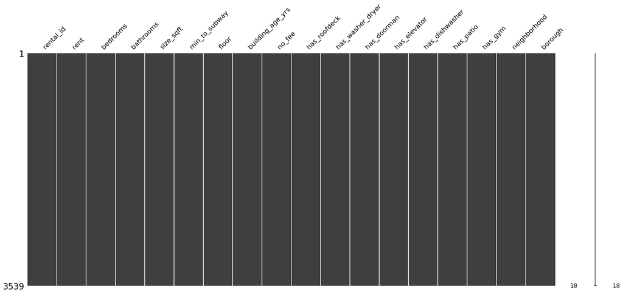

```python
# insert code here
msno.matrix(df)
plt.show()
```

**1.4 Does variable "rent" has outliers?**

```python
# insert code here
df.rent.describe()
```

```
count     3539.000000
mean      5138.940379
std       3162.824760
min       1300.000000
25%       3150.000000
50%       4000.000000
75%       6000.000000
max      20000.000000
Name: rent, dtype: float64
```

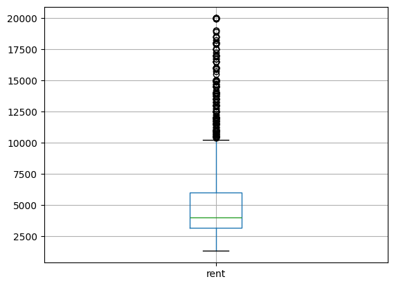

```python
df[['rent']].boxplot()
plt.show()
```

**1.5 What about the logarithm of rent?**

We see from the boxplot below that the natural log of rent still has a few outliers. However, there are much fewer than before.

```python
# insert code here
df['lg_rent'] = np.log(df.rent)
```

```python
df.lg_rent.describe()
```

```
count    3539.000000
mean        8.403007
std         0.506105
min         7.170120
25%         8.055158
50%         8.294050
75%         8.699515
max         9.903488
Name: lg_rent, dtype: float64
```

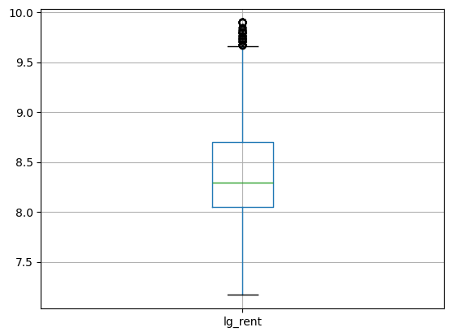

```python
df[["lg_rent"]].boxplot()
```

## 2. Multivariate Analysis

**2.1 Calculate the Pearson correlation of all numeric variables. Which of the variable has the highest correlation to rent? What is your explanation?**

The variable with the highest correlation is the one for log rent ("lg_rent") that we created for the previous question. This is unsurprising given that log rent is calculated based on the values of rent.

However, the variable with the highest correlation excluding log rent is the variable for square feet ("size_sqft").

```python
# insert code here
df.select_dtypes(include='number').corr(method="pearson")
```

|  | rental_id | rent | bedrooms | bathrooms | size_sqft | min_to_subway | floor | building_age_yrs | no_fee | has_roofdeck | has_washer_dryer | has_doorman | has_elevator | has_dishwasher | has_patio | has_gym | lg_rent |
| --- | --- | --- | --- | --- | --- | --- | --- | --- | --- | --- | --- | --- | --- | --- | --- | --- | --- |
| rental_id | 1.000000 | -0.134347 | -0.070290 | -0.109414 | -0.107711 | 0.009615 | -0.082586 | 0.028543 | 0.064919 | -0.023335 | -0.072738 | -0.057786 | -0.060152 | -0.029615 | -0.004253 | -0.023457 | -0.148649 |
| rent | -0.134347 | 1.000000 | 0.638336 | 0.769474 | 0.857954 | 0.035164 | 0.215867 | -0.128895 | -0.101497 | 0.035165 | 0.053873 | 0.031302 | 0.051860 | 0.052241 | 0.029302 | 0.040609 | 0.948965 |
| bedrooms | -0.070290 | 0.638336 | 1.000000 | 0.720885 | 0.771263 | 0.076543 | 0.043539 | 0.037228 | -0.100352 | 0.002938 | 0.008721 | -0.017331 | -0.006771 | 0.005467 | 0.003037 | -0.004112 | 0.672965 |
| bathrooms | -0.109414 | 0.769474 | 0.720885 | 1.000000 | 0.803627 | 0.086932 | 0.127969 | -0.095421 | -0.062205 | 0.019556 | 0.025752 | 0.014745 | 0.021150 | 0.038829 | 0.042304 | 0.029739 | 0.756607 |
| size_sqft | -0.107711 | 0.857954 | 0.771263 | 0.803627 | 1.000000 | 0.039448 | 0.107186 | 0.014489 | -0.141451 | 0.024822 | 0.038263 | 0.026098 | 0.040916 | 0.050364 | 0.021921 | 0.029347 | 0.841779 |
| min_to_subway | 0.009615 | 0.035164 | 0.076543 | 0.086932 | 0.039448 | 1.000000 | 0.082445 | -0.184682 | 0.080088 | -0.020693 | -0.001327 | -0.009012 | -0.000410 | -0.012244 | 0.001500 | -0.004315 | 0.031667 |
| floor | -0.082586 | 0.215867 | 0.043539 | 0.127969 | 0.107186 | 0.082445 | 1.000000 | -0.389260 | 0.104317 | 0.056322 | 0.038870 | 0.095963 | 0.068917 | 0.002337 | 0.059423 | 0.065410 | 0.257455 |
| building_age_yrs | 0.028543 | -0.128895 | 0.037228 | -0.095421 | 0.014489 | -0.184682 | -0.389260 | 1.000000 | -0.221429 | -0.041305 | -0.030014 | -0.047265 | -0.060627 | -0.027420 | -0.050321 | -0.063110 | -0.199437 |
| no_fee | 0.064919 | -0.101497 | -0.100352 | -0.062205 | -0.141451 | 0.080088 | 0.104317 | -0.221429 | 1.000000 | -0.095718 | -0.070324 | -0.182547 | -0.161519 | -0.078660 | -0.049684 | -0.101230 | -0.049088 |
| has_roofdeck | -0.023335 | 0.035165 | 0.002938 | 0.019556 | 0.024822 | -0.020693 | 0.056322 | -0.041305 | -0.095718 | 1.000000 | 0.313459 | 0.489836 | 0.516534 | 0.331999 | 0.122568 | 0.561626 | 0.038621 |
| has_washer_dryer | -0.072738 | 0.053873 | 0.008721 | 0.025752 | 0.038263 | -0.001327 | 0.038870 | -0.030014 | -0.070324 | 0.313459 | 1.000000 | 0.328291 | 0.379999 | 0.455166 | 0.140979 | 0.348433 | 0.063377 |
| has_doorman | -0.057786 | 0.031302 | -0.017331 | 0.014745 | 0.026098 | -0.009012 | 0.095963 | -0.047265 | -0.182547 | 0.489836 | 0.328291 | 1.000000 | 0.717929 | 0.343159 | 0.140968 | 0.633628 | 0.044273 |
| has_elevator | -0.060152 | 0.051860 | -0.006771 | 0.021150 | 0.040916 | -0.000410 | 0.068917 | -0.060627 | -0.161519 | 0.516534 | 0.379999 | 0.717929 | 1.000000 | 0.419812 | 0.134536 | 0.642099 | 0.060750 |
| has_dishwasher | -0.029615 | 0.052241 | 0.005467 | 0.038829 | 0.050364 | -0.012244 | 0.002337 | -0.027420 | -0.078660 | 0.331999 | 0.455166 | 0.343159 | 0.419812 | 1.000000 | 0.133127 | 0.342590 | 0.062877 |
| has_patio | -0.004253 | 0.029302 | 0.003037 | 0.042304 | 0.021921 | 0.001500 | 0.059423 | -0.050321 | -0.049684 | 0.122568 | 0.140979 | 0.140968 | 0.134536 | 0.133127 | 1.000000 | 0.123524 | 0.033942 |
| has_gym | -0.023457 | 0.040609 | -0.004112 | 0.029739 | 0.029347 | -0.004315 | 0.065410 | -0.063110 | -0.101230 | 0.561626 | 0.348433 | 0.633628 | 0.642099 | 0.342590 | 0.123524 | 1.000000 | 0.043382 |
| lg_rent | -0.148649 | 0.948965 | 0.672965 | 0.756607 | 0.841779 | 0.031667 | 0.257455 | -0.199437 | -0.049088 | 0.038621 | 0.063377 | 0.044273 | 0.060750 | 0.062877 | 0.033942 | 0.043382 | 1.000000 |

**2.2 Do a scatter plot between rent and the variable in your answer for the previous question. What do you find?**

As expected, we see that there appears to be a strong positive relationship between the size of the unit in square feet and the rental price. Additionally, it appears that the correlation may be somewhat weaker at higher prices. For instance, above a rental price of around $15,000 there does not seem to be a strong relationship between rent and square feet.

I am also curious about the outlier value in the top left corner of the scatter plot for the unit that is around $18,000 for less than 1,000 square feet. It seems surprising to me that a unit that small could be worth such a high rent (assuming it is not an error in the data).

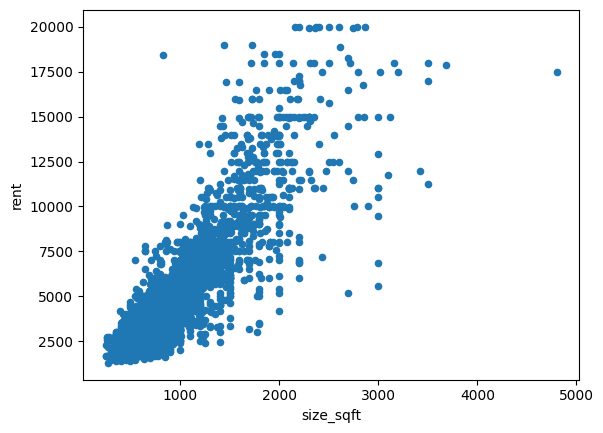

```python
# insert code here
df.plot.scatter("size_sqft","rent")
plt.show()
```

**2.3 Normalize the rent by that variable (through division), call it `norm_rent`, and calculate its correlation with that selected feature. What do you find?**

The variable "norm_rent" that we created measures the rental price per square foot. We see from the correlation table that price per square foot has a weak relationship with square footage. This makes sense based on the scatter plot in the previous question, as it seemed that prices largely increase proportionally to square feet.

```python
# insert code here
df["norm_rent"] = df.rent / df.size_sqft

df[["norm_rent", "size_sqft"]].corr(method="pearson")
```

|  | norm_rent | size_sqft |
| --- | --- | --- |
| norm_rent | 1.000000 | 0.020864 |
| size_sqft | 0.020864 | 1.000000 |

**2.4 Based on the normalized rent, re-do question 2.1 and find the most correlated feature.**

The most correlated features are log rent and rent. This is interesting as it shows that more expensive units are also usually more expensive per square foot. Expensive units are not simply more expensive because they are larger, but because they likely provide other amenities that renters value. For example, we see that, after price and log price, the next most correlated variables are building age and floor, because renters are willing to pay more per square foot for units in newer buildings on higher floors.

```python
# insert code here
df.select_dtypes(include='number').corr(method="pearson")['norm_rent']
```

```
rental_id          -0.091065
rent                0.473643
bedrooms           -0.056876
bathrooms           0.150398
size_sqft           0.020864
min_to_subway      -0.031655
floor               0.251412
building_age_yrs   -0.299958
no_fee              0.107109
has_roofdeck        0.013869
has_washer_dryer    0.042595
has_doorman         0.006243
has_elevator        0.021911
has_dishwasher      0.023373
has_patio           0.013430
has_gym             0.018418
lg_rent             0.477410
norm_rent           1.000000
Name: norm_rent, dtype: float64
```

## 3. Regression Analysis

**3.1 Do a regression analysis according to the following specification:**

$$ \log(\text{rent}) \sim \text{min_to_subway} + \log(\text{building_age_yrs}) + \log(\text{size_sqft}) + \text{no_fee} + \text{bedrooms} + \text{bathrooms} $$

**Report $\hat{\beta}$, standard error, t-statistics, p-value, and $R^2$.**

Below, we see that the R-squared is .792, meaning that 79.2% of the variance in rent price is explained by the independent variables in the model. We also see that the coefficients for the independent variables are all statistically significant at the 95% confidence level (t-stat > 1.96). Interestingly, we see that the coefficient for bedrooms is negative. This means that increasing bedrooms has a negative impact on price when holding the other independent variables constant.

```python
# insert code here
df['lg_age'] = np.log1p(df.building_age_yrs) # we use the np.log1p function instead of np.log as there are some 0 values in the data
df['lg_sqft'] = np.log1p(df.size_sqft)
X = df[['min_to_subway','lg_age','lg_sqft','no_fee','bedrooms','bathrooms']]
y = df['lg_rent']
X = sm.add_constant(X)
model = sm.OLS(y, X)
result = model.fit()
result.summary()
```

OLS Regression Results

| Dep. Variable: | lg_rent | R-squared: | 0.792 |
| --- | --- | --- | --- |
| Model: | OLS | Adj. R-squared: | 0.792 |
| Method: | Least Squares | F-statistic: | 2241. |
| Date: | Sun, 28 Jan 2024 | Prob (F-statistic): | 0.00 |
| Time: | 10:23:15 | Log-Likelihood: | 167.08 |
| No. Observations: | 3539 | AIC: | -320.2 |
| Df Residuals: | 3532 | BIC: | -277.0 |
| Df Model: | 6 |  |  |
| Covariance Type: | nonrobust |  |  |

|  | coef | std err | t | P>\|t\| | [0.025 | 0.975] |
| --- | --- | --- | --- | --- | --- | --- |
| const | 2.6665 | 0.106 | 25.180 | 0.000 | 2.459 | 2.874 |
| min_to_subway | -0.0044 | 0.001 | -6.076 | 0.000 | -0.006 | -0.003 |
| lg_age | -0.0804 | 0.004 | -20.595 | 0.000 | -0.088 | -0.073 |
| lg_sqft | 0.8672 | 0.017 | 50.733 | 0.000 | 0.834 | 0.901 |
| no_fee | 0.0286 | 0.008 | 3.498 | 0.000 | 0.013 | 0.045 |
| bedrooms | -0.0548 | 0.007 | -7.605 | 0.000 | -0.069 | -0.041 |
| bathrooms | 0.1913 | 0.011 | 17.880 | 0.000 | 0.170 | 0.212 |

| Omnibus: | 174.282 | Durbin-Watson: | 2.064 |
| --- | --- | --- | --- |
| Prob(Omnibus): | 0.000 | Jarque-Bera (JB): | 571.821 |
| Skew: | -0.144 | Prob(JB): | 6.77e-125 |
| Kurtosis: | 4.948 | Cond. No. | 275. |

Notes:  
[1] Standard Errors assume that the covariance matrix of the errors is correctly specified.

**3.2 How do you interpret the coefficient on $\log(\text{size_sqft})$?**

**3.3 Remove $\log(\text{size_sqft})$ from the independent variables, and re-do the above regression keeping the independent variables fixed. Report the result.**

```python
# insert code here
X = df[['min_to_subway','lg_age','no_fee','bedrooms','bathrooms']]
y = df['lg_rent']
X = sm.add_constant(X)
model = sm.OLS(y, X)
result = model.fit()
result.summary()
```

OLS Regression Results

| Dep. Variable: | lg_rent | R-squared: | 0.640 |
| --- | --- | --- | --- |
| Model: | OLS | Adj. R-squared: | 0.640 |
| Method: | Least Squares | F-statistic: | 1258. |
| Date: | Sun, 28 Jan 2024 | Prob (F-statistic): | 0.00 |
| Time: | 17:53:25 | Log-Likelihood: | -801.50 |
| No. Observations: | 3539 | AIC: | 1615. |
| Df Residuals: | 3533 | BIC: | 1652. |
| Df Model: | 5 |  |  |
| Covariance Type: | nonrobust |  |  |

|  | coef | std err | t | P>\|t\| | [0.025 | 0.975] |
| --- | --- | --- | --- | --- | --- | --- |
| const | 7.9481 | 0.025 | 311.905 | 0.000 | 7.898 | 7.998 |
| min_to_subway | -0.0063 | 0.001 | -6.627 | 0.000 | -0.008 | -0.004 |
| lg_age | -0.0913 | 0.005 | -17.820 | 0.000 | -0.101 | -0.081 |
| no_fee | -0.0164 | 0.011 | -1.535 | 0.125 | -0.037 | 0.005 |
| bedrooms | 0.1579 | 0.008 | 20.494 | 0.000 | 0.143 | 0.173 |
| bathrooms | 0.4421 | 0.012 | 35.436 | 0.000 | 0.418 | 0.467 |

| Omnibus: | 121.997 | Durbin-Watson: | 2.063 |
| --- | --- | --- | --- |
| Prob(Omnibus): | 0.000 | Jarque-Bera (JB): | 205.935 |
| Skew: | 0.296 | Prob(JB): | 1.91e-45 |
| Kurtosis: | 4.023 | Cond. No. | 42.3 |

Notes:  
[1] Standard Errors assume that the covariance matrix of the errors is correctly specified.

**3.4 Compare the results to the former one. Which $\hat{\beta}$ s have different signs or significance levels? What is your interpretation?**

There are a couple of changes in the model results when we remove log square feet from the independent variables.

First, we notice that the "no_fee" variable is no longer statistically significant at the 95% level (t-stat: -1.535), and its sign has become negative. I would interpret this as being because the "no_fee" units are smaller than fee units on average, so without a square feet variable in the model the no-fee variable captures some of the effects of unit size.

Additionally, we notice that the sign on the bedrooms variable has become positive, and the magnitude of the bathrooms variable has increased. This is probably because both of these variables are often proxies for square footage, as more bathrooms and bedrooms require additional square footage. Thus, without square footage the impact of these variables becomes higher and more positive. However, sometimes more expensive units are large units with relatively few bedrooms relative to their square footage, so when square footage is controlled for bedrooms actually have a negative impact.

```python
df.groupby("no_fee")['size_sqft'].mean()
```

```
no_fee
0    995.323543
1    857.539916
Name: size_sqft, dtype: float64
```